# Workshop 10: Scales and Themes live demo

Joy Vaz

2022-07-12

# ggplot2 live demo: Scales and Themes

Your assignment for the first part of this workshop is to recreate a plot from the [EpiGraphHub COVID-19 Switzerland dashboard](https://epigraphhub.org/superset/dashboard/11) in R using {ggplot2}.

The graph we are aiming for looks like this:

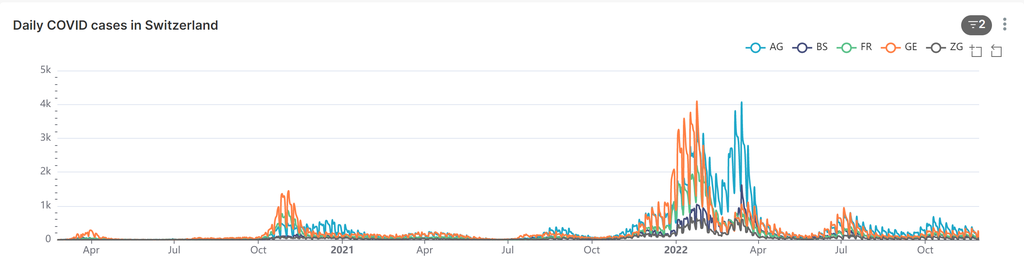

Now most of the elements shown here you have already learned how to create: line graph, group into regions by color, add labels.

However, there are additional modifications we want to make to the scales and themes.

I will demonstrate how to do this using a sample dataset with fake data.

The structure of the data frame is similar to what you will use for the workshop assignment:

```r
head(sample_df)
```

```
##         date district fake_cases
## 1 2022-01-01       D1       8916
## 2 2022-01-02       D2       2092
## 3 2022-01-03       D3       5379
## 4 2022-01-04       D1       7322
## 5 2022-01-05       D2       4241
## 6 2022-01-06       D3       3827
```

We can use this to make a simple time series plot using `ggplot()`.

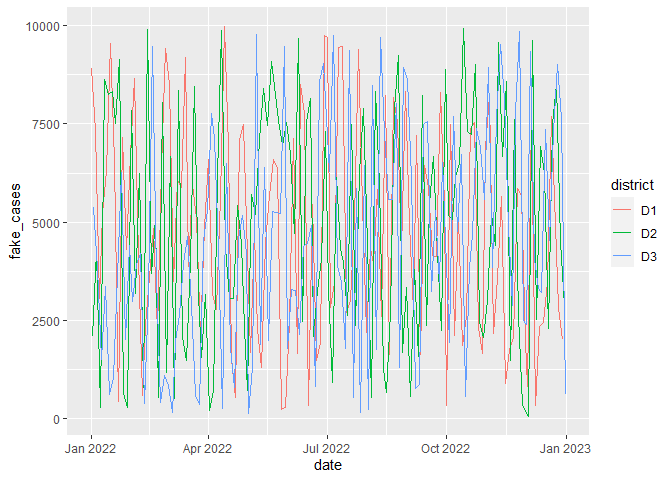

```r
# Create base plot
base_plot <- ggplot(data = sample_df,
  mapping = aes(x = date,
    y = fake_cases,
    color = district)) +
  geom_line()

base_plot
```

We can add additional ggplot layers to `base_plot`, like so:

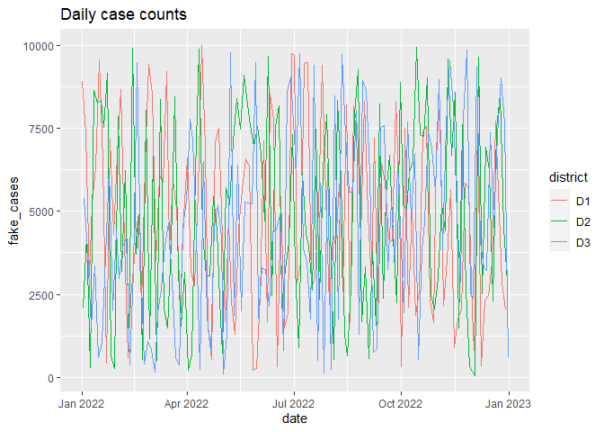

```r
# Add title
base_plot +
  labs(title = "Daily case counts")
```

In order to match the look of the plot we are aiming for, we need to do the following:

1. Change background from gray to white
2. Relabel x-axis scale breaks to month abbreviations
3. Remove axis titles
4. Remove most grid lines
5. Relabel y-axis scale breaks to shorten 1000s to “k”

We can do this with **scale** and **theme** functions from ggplot2.

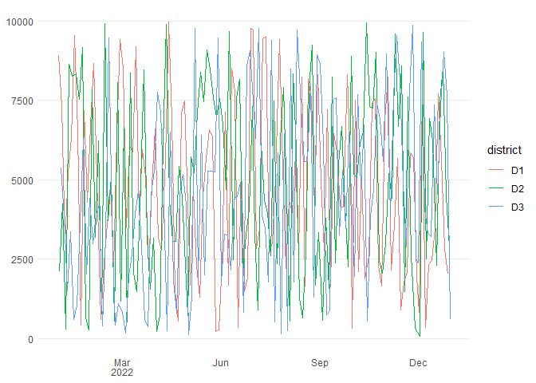

```r
enhanced_plot <- base_plot +
  theme_minimal() +
  theme(axis.title = element_blank(),
    panel.grid.minor = element_blank(),
    panel.grid.major.x = element_blank()) +
  scale_x_date(date_breaks = "3 months",
    labels = label_date_short())

enhanced_plot
```

Four out of five tasks done!

We leave the last and step to you. Do some web searches or use ChatGPT to learn how to shorten the y-axis numbers to add a “K” suffix. This is so that you can practice self-learning, and using external resources, such as [this tutorial](https://www.roelpeters.be/scale-ggplot-y-axis-millions-or-thousands-r/) to your own datasets.